# Affect of Household income on

## Description and Interpretation of Results

In this analysis, 4 different simple linear regressions were run with Zip Income (the median income in a zipcode) as the explanatory variable and different admissions factors as the response variables. In particular, the admissions factors that were looked at were: average ACT score, number of students who applied to Georgia Tech, number of students who were accepted into Georgia Tech, and average year one GPA at Georgia Tech. In an initial attempt to run the regression with just Zip Income, some problems arose because there was a very small amount of variation in the response variables, but a very large amount of variation in the Zip Income explanatory variable. To alleviate this a log transformation of Zip Income was used to account for the variation. The result was a more accurate linear regression.  
We ran a regression and created a scatterplot for each pair of variables. General findings show that there is a positive correlation between median household zip code income and number accepted into Georgia Tech. One major reason for this is that higher income areas have access to better resources to prepare them for college such as: SAT/ACT prep courses, better education systems, academic counselors, and a plethora of Advanced Placement courses. Lower income areas may not have access to comparable resources. This is supported by the positive correlation between ACT scores and Zip Income. Although it appears Tech accepts an increasing number of applicants from higher income areas compared to lower income areas, the average year one GPA at Tech versus Zip Income regression and scatterplot show that students from higher income levels have slightly higher year one GPAs, but all admitted Tech students perform pretty comparably despite income levels.

### Zip Income vs Accepted

```r
regress1 <- lm(Accepted ~ log(ZIP_MEDIAN_HOUSEHOLD_INCOME), data=FinallyTable)

stargazer(regress1, type='html')
```

|  | *Dependent variable:* |
| --- | --- |
|  | Accepted |
| log(ZIP_MEDIAN_HOUSEHOLD_INCOME) | 66.281*** |
|  | (10.541) |
| Constant | -668.861*** |
|  | (115.002) |
| Observations | 166 |
| R<sup>2</sup> | 0.194 |
| Adjusted R<sup>2</sup> | 0.189 |
| Residual Std. Error | 51.776 (df = 164) |
| F Statistic | 39.536*** (df = 1; 164) |
| *Note:* | p<0.1; p<0.05; p<0.01 |

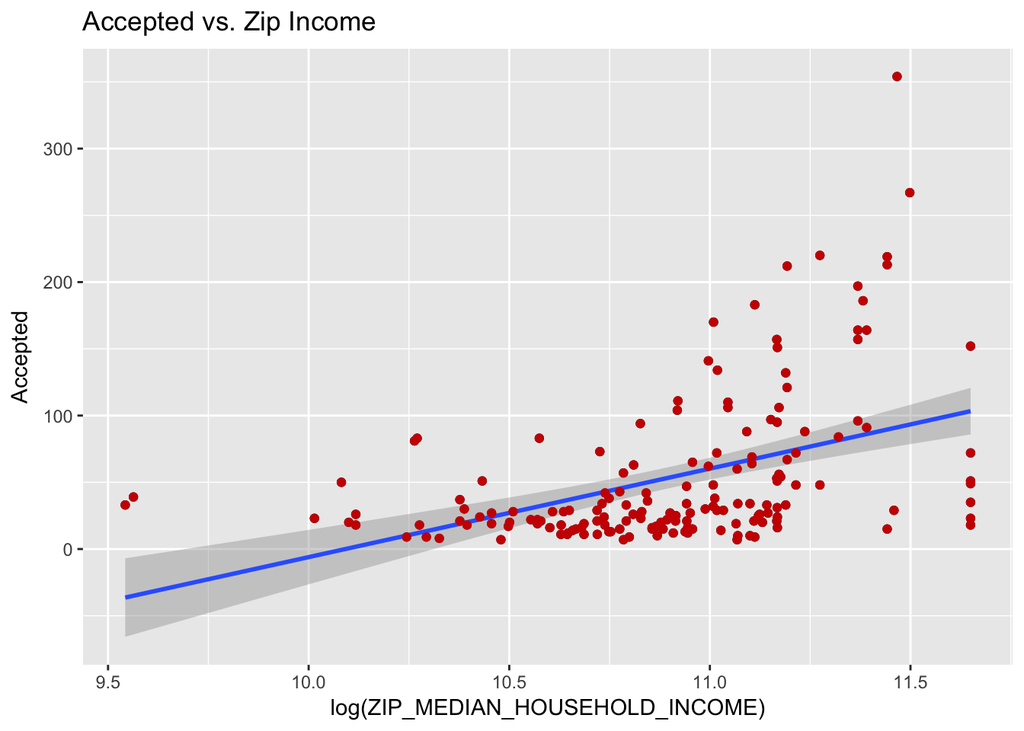

```r
ggplot(FinallyTable, aes(x=log(ZIP_MEDIAN_HOUSEHOLD_INCOME), y=`Accepted`)) +
    geom_point() +
    geom_smooth(method=lm)+
    ggtitle("Accepted vs. Zip Income")+
    geom_point(color = "red3")
```

Scatterplot shows a positive relationship between two variables.

regress1 (Accepted vs Zip Income) - The coefficient on log(Zip Income) means that a 1% increase in Zip Income leads to a (66.281/100) increase in the amount of people accepted. The intercept means that the amount of people accepted has a predicted value of -668.861 people when Zip Income equals 0. The p-values for both the intercept and slope are less than 0.01 so both are statistically significant. The R-square value shows that 19.4% of the variation is explained by the model.

### Zip Income vs ACT Average

```r
regress2 <- lm(ACT_AVG ~ log(ZIP_MEDIAN_HOUSEHOLD_INCOME), data=FinallyTable)

stargazer(regress2, type='html')
```

|  | *Dependent variable:* |
| --- | --- |
|  | ACT_AVG |
| log(ZIP_MEDIAN_HOUSEHOLD_INCOME) | 1.334*** |
|  | (0.246) |
| Constant | 16.117*** |
|  | (2.688) |
| Observations | 166 |
| R<sup>2</sup> | 0.152 |
| Adjusted R<sup>2</sup> | 0.147 |
| Residual Std. Error | 1.210 (df = 164) |
| F Statistic | 29.323*** (df = 1; 164) |
| *Note:* | p<0.1; p<0.05; p<0.01 |

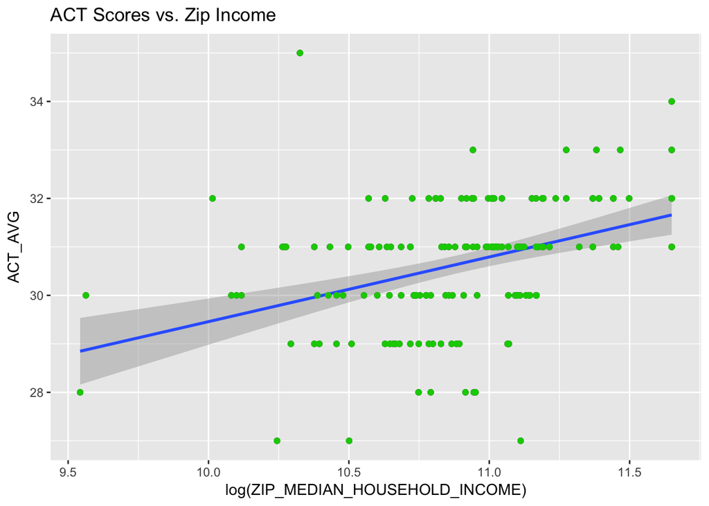

```r
ggplot(FinallyTable, aes(x=log(ZIP_MEDIAN_HOUSEHOLD_INCOME), y=`ACT_AVG`)) +
    geom_point() +
    geom_smooth(method=lm)+
    ggtitle("ACT Scores vs. Zip Income")+
    geom_point(color = "green3")
```

Scatterplot shows a positive relationship between two variables.

regress2 (ACT scores vs Zip Income) - The coefficient of log(Zip Income) means that a 1% increase in Zip Income leads to a (1.334/100) increase in average ACT score. The intercept means that the average ACT score has a predicted value of 16.117 when Zip Income equals 0. The p-values for both the intercept and slope are less than 0.01 so both are statistically significant. The R-square value shows that 15.2% of the variation is explained by the model.

### Zip Income vs Year One GPA

```r
regress3 <- lm(`YEAR_ONE_GPA_AVG` ~ log(ZIP_MEDIAN_HOUSEHOLD_INCOME), data=FinallyTable)

stargazer(regress3, type='html')
```

|  | *Dependent variable:* |
| --- | --- |
|  | YEAR_ONE_GPA_AVG |
| log(ZIP_MEDIAN_HOUSEHOLD_INCOME) | 0.121*** |
|  | (0.041) |
| Constant | 2.010*** |
|  | (0.451) |
| Observations | 166 |
| R<sup>2</sup> | 0.050 |
| Adjusted R<sup>2</sup> | 0.044 |
| Residual Std. Error | 0.203 (df = 164) |
| F Statistic | 8.652*** (df = 1; 164) |
| *Note:* | p<0.1; p<0.05; p<0.01 |

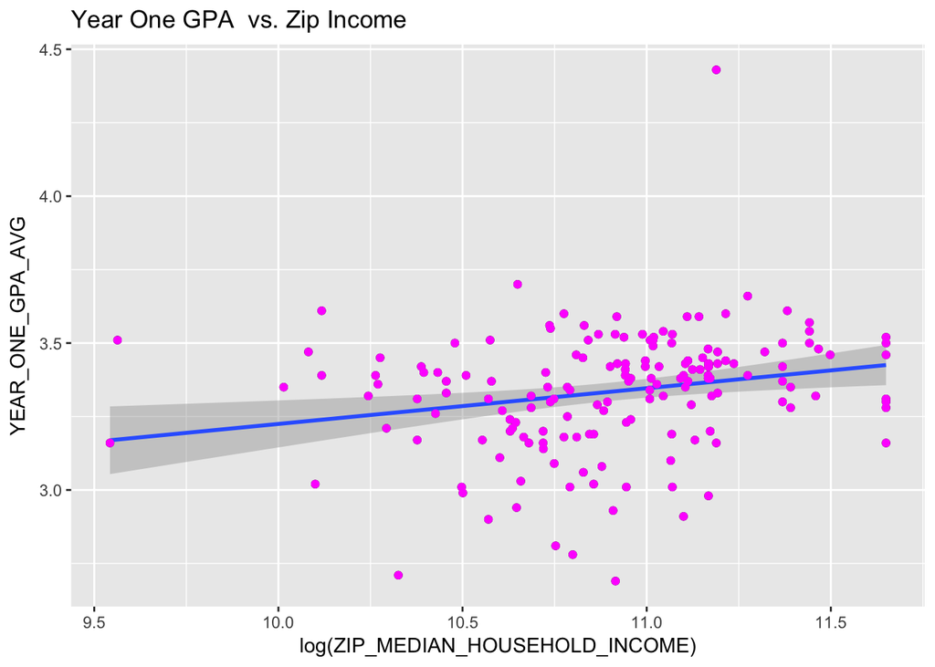

```r
ggplot(FinallyTable, aes(x=log(ZIP_MEDIAN_HOUSEHOLD_INCOME), y=`YEAR_ONE_GPA_AVG`)) +
    geom_point() +
    geom_smooth(method=lm)+
    ggtitle("Year One GPA  vs. Zip Income")+
    geom_point(color = "magenta")
```

Scatterplot shows a positive relationship between two variables.

regress3 (Year One GPA vs Zip Income) - The coefficient of log(Zip Income) means that a 1% increase in Zip Income leads to a (.121/100) increase in average Year One GPA. The intercept means that the average Year One GPA has a predicted value of 2.010 when Zip Income equals 0. The p-values for both the intercept and slope are less than 0.01 so both are statistically significant. The R-square value shows that 5.0% of the variation is explained by the model.

### Zip Income vs Number of Students Applied

```r
regress4 <- lm(`Applied` ~ log(ZIP_MEDIAN_HOUSEHOLD_INCOME), data=FinallyTable)

stargazer(regress4, type='html')
```

|  | *Dependent variable:* |
| --- | --- |
|  | Applied |
| log(ZIP_MEDIAN_HOUSEHOLD_INCOME) | 150.408*** |
|  | (23.375) |
| Constant | -1,512.031*** |
|  | (255.018) |
| Observations | 166 |
| R<sup>2</sup> | 0.202 |
| Adjusted R<sup>2</sup> | 0.197 |
| Residual Std. Error | 114.815 (df = 164) |
| F Statistic | 41.403*** (df = 1; 164) |
| *Note:* | p<0.1; p<0.05; p<0.01 |

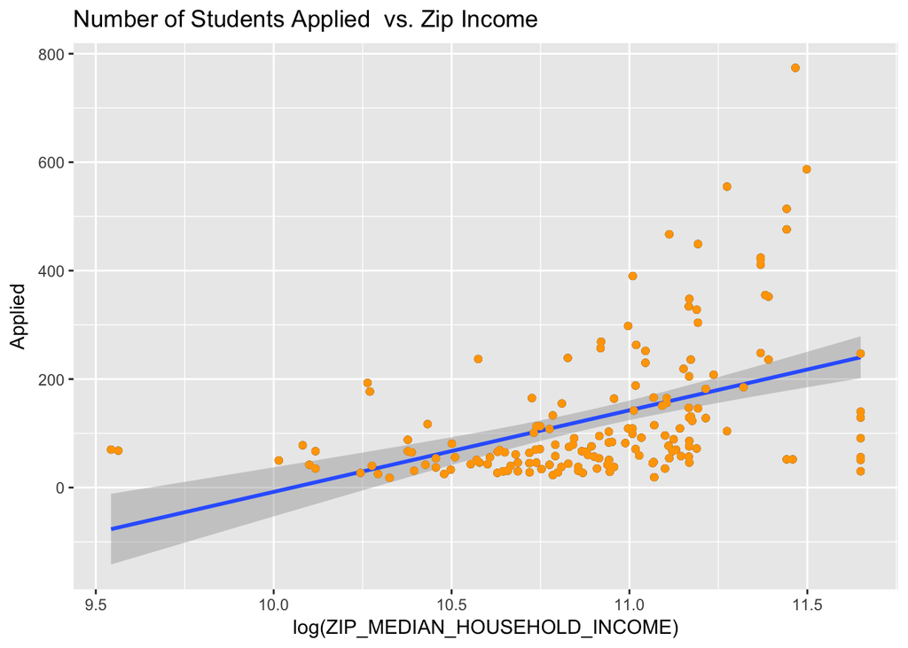

```r
ggplot(FinallyTable, aes(x=log(ZIP_MEDIAN_HOUSEHOLD_INCOME), y=`Applied`)) +
    geom_point() +
    geom_smooth(method=lm)+
    ggtitle("Number of Students Applied  vs. Zip Income")+
    geom_point(color = "orange")
```

Scatterplot shows a positive relationship between two variables.

regress4 (Number of Students Applied vs Zip Income) - The coefficient of log(Zip Income) means that a 1% increase in Zip Income leads to a (150.408/100) increase in Number of Students Applied. The intercept means that the Number of People Applied has a predicted value of -1,512.031 when Zip Income equals 0. The p-values for both the intercept and slope are less than 0.01 so both are statistically significant. The R-square value shows that 20.2% of the variation is explained by the model.

## Business Implications

The findings of the research project have many important implications for businesses and Georgia Tech, particularly for admissions decisions. The following is a discussion of some of the implications that our results have for businesses.

One of the major reasons that Georgia Tech might be admitting more prospective students from higher income areas is because “family income not only has a huge correlation with the chance that a kid gets into college, but of that person’s likelihood of actually graduating” (Sherman 2015). Georgia Tech doesn’t want to admit students who they believe might not graduate because it affects the graduation rates from the Institute and portrays the Institute in a negative light.

In a study conducted by Forbes, data scientists looked at Bachelor’s Degree attainment rates by age 24 for dependent family members who entered college. The study found that if “your family is from the top quartile of income and you get accepted to college, you have a 99% chance to finish at least a bachelor’s” (Sherman 2015). Perhaps Georgia Tech is accepting more students from high income areas because they know these students are much more likeley to graduate. Or perhaps Georgia Tech is accepting the best applicants who seem to be likeley graduates and it just so happens that they are from high income areas.

Our results also indicate that students applying to Georgia Tech from schools in higher income areas will have a slightly higher year one GPA. Students with higher GPAs are usually more likely to receive better/higher paying job offers upon graduation, and so Georgia Tech might admit these students with the prospect of receiving more future alumni donations from them. Again, Georgia Tech might be accepting more applicants from higher income areas; or the applicants they believe to be succesful at Georgia Tech are coincidentally from higher income areas.

Students from lower income families/zip codes might also require larger amounts of financial aid. Georgia Tech’s 2016 endowment was $1.844B, so while this seems like a lot of money (which it is), Georgia Tech is still on a budget and cannot grant financial aid to every single student. If a student is seeking financial aid and not extremely competitive, the Institute might not accept that student because they want to reserve their financial aid for more competitive applicants.

Lower income high schools don’t have the resources to compete with higher income schools. When an applicant applies to Georgia Tech, the applicant’s high school also submits a high school profile to the Institute. This school profile includes but is not limited to information such as college admissions rates, advanced placement classes offered by the school, share of students who qualify for free and reduced-price lunches, demographics, etc. Lower income schools simply don’t have the resources to provide more than the bare minimum information, whereas higher income schools have access to much more detailed and accurate school profiles. In fact, “admissions officers were 26% more likeley to recommend low-income students when provided detailed information about them and their high schools” (Berman 2017). Georgia Tech is accepting the most qualified applicants; however, these applicants might appear to be more qualified based off the amount of resources/income that their respective high schools have. Higher income schools also offer more extensive college counseling, application essay practice, SAT/ACT prep courses, etc.

Lastly, our results state that students from higher income areas will have higher ACT scores. This is likeley a result of two major factors. First, standardized testing prep courses and tutors are very expensive. Instructor led courses can cost up to $1,000 while private tutors demand the high price of up to $195 per session. Higher income applicants can afford these steep prices while lower income applicants might not. Many private schools as well as high income/resource public schools offer students an SAT/ACT prep course that students can take for a semester in order to prepare for their standardized tests. Again, high income schools have the resources to offer these courses while low income schools do not.

## References

Parker, Timothy. “United States Department of Agriculture Economic Research Service.” United States Department of Agriculture Economic Research Service, USDA, 25 Jan. 2018, data.ers.usda.gov/reports.aspx?ID=17828.

“Zip Codes with the Highest Median Household Income in Georgia.” Zip Codes with the Highest Median Household Income in Georgia, ZipAtlas, zipatlas.com/us/ga/zip-code-comparison/median-household-income.htm.

Goldfarb, Zachary A. “These Four Charts Show How the SAT Favors Rich, Educated Families.” The Washington Post, WP Company, 5 Mar. 2014, www.washingtonpost.com/news/wonk/wp/2014/03/05/these-four-charts-show-how-the-sat-favors-the-rich-educated-families/?utm_term=.d7de8b524243&noredirect=on.

Berman, Jillian. “Why College Admissions Officers Overlook Low-Income Students.” MarketWatch, 20 Apr. 2017, www.marketwatch.com/story/why-college-admissions-officers-overlook-low-income-students-2017-04-17.

Sherman, Erik. “Wealthy Kids 8 Times More Likely To Graduate College Than Poor.” Forbes, Forbes Magazine, 16 Apr. 2017, www.forbes.com/sites/eriksherman/2015/02/05/wealthy-college-kids-8-times-more-likely-to-graduate-than-poor/#33918026dfbd.

http://irp.gatech.edu/admission-snapshots-0

https://www.gadoe.org/Documents/ga_public_school_contact_list.xls